# Lab 2 analysis — R

Primary Biliary Cholangitis Data from Mayo Clinical Trial conducted between 1974 and 1984. A total of 424 PBC patients, referred to Mayo Clinic during that ten-year interval, met eligibility criteria for the randomized placebo controlled trial of the drug D-penicillamine. The first 312 cases in the data set participated in the randomized trial and contain largely complete data. The additional 112 cases did not participate in the clinical trial, but consented to have basic measurements recorded and to be followed for survival. Six of those cases were lost to follow-up shortly after diagnosis, so the data here are on an additional 106 cases as well as the 312 randomized participants.

Primmary Biliary Cholangitis (PBC) is an autoimmune disease which leads to the destruction of small bile ducts in the the liver.

Full documentation: PBC dataset (Rdatasets)

```r
library(tidyverse)
library(survival)
data(pbc)
```

# Exploratory Data Analysis

```r
head(pbc)
```

```
##   id time status trt      age sex ascites hepato spiders edema bili chol albumin copper alk.phos
## 1  1  400      2   1 58.76523   f       1      1       1   1.0 14.5  261    2.60    156   1718.0
## 2  2 4500      0   1 56.44627   f       0      1       1   0.0  1.1  302    4.14     54   7394.8
## 3  3 1012      2   1 70.07255   m       0      0       0   0.5  1.4  176    3.48    210    516.0
## 4  4 1925      2   1 54.74059   f       0      1       1   0.5  1.8  244    2.54     64   6121.8
## 5  5 1504      1   2 38.10541   f       0      1       1   0.0  3.4  279    3.53    143    671.0
## 6  6 2503      2   2 66.25873   f       0      1       0   0.0  0.8  248    3.98     50    944.0
##      ast trig platelet protime stage
## 1 137.95  172      190    12.2     4
## 2 113.52   88      221    10.6     3
## 3  96.10   55      151    12.0     4
## 4  60.63   92      183    10.3     4
## 5 113.15   72      136    10.9     3
## 6  93.00   63       NA    11.0     3
```

```r
summary(pbc)
```

```
##        id             time          status            trt             age        sex
##  Min.   :  1.0   Min.   :  41   Min.   :0.0000   Min.   :1.000   Min.   :26.28   m: 44
##  1st Qu.:105.2   1st Qu.:1093   1st Qu.:0.0000   1st Qu.:1.000   1st Qu.:42.83   f:374
##  Median :209.5   Median :1730   Median :0.0000   Median :1.000   Median :51.00
##  Mean   :209.5   Mean   :1918   Mean   :0.8301   Mean   :1.494   Mean   :50.74
##  3rd Qu.:313.8   3rd Qu.:2614   3rd Qu.:2.0000   3rd Qu.:2.000   3rd Qu.:58.24
##  Max.   :418.0   Max.   :4795   Max.   :2.0000   Max.   :2.000   Max.   :78.44
##                                                  NA's   :106
##     ascites            hepato          spiders           edema             bili
##  Min.   :0.00000   Min.   :0.0000   Min.   :0.0000   Min.   :0.0000   Min.   : 0.300
##  1st Qu.:0.00000   1st Qu.:0.0000   1st Qu.:0.0000   1st Qu.:0.0000   1st Qu.: 0.800
##  Median :0.00000   Median :1.0000   Median :0.0000   Median :0.0000   Median : 1.400
##  Mean   :0.07692   Mean   :0.5128   Mean   :0.2885   Mean   :0.1005   Mean   : 3.221
##  3rd Qu.:0.00000   3rd Qu.:1.0000   3rd Qu.:1.0000   3rd Qu.:0.0000   3rd Qu.: 3.400
##  Max.   :1.00000   Max.   :1.0000   Max.   :1.0000   Max.   :1.0000   Max.   :28.000
##  NA's   :106       NA's   :106      NA's   :106
##       chol           albumin          copper          alk.phos            ast
##  Min.   : 120.0   Min.   :1.960   Min.   :  4.00   Min.   :  289.0   Min.   : 26.35
##  1st Qu.: 249.5   1st Qu.:3.243   1st Qu.: 41.25   1st Qu.:  871.5   1st Qu.: 80.60
##  Median : 309.5   Median :3.530   Median : 73.00   Median : 1259.0   Median :114.70
##  Mean   : 369.5   Mean   :3.497   Mean   : 97.65   Mean   : 1982.7   Mean   :122.56
##  3rd Qu.: 400.0   3rd Qu.:3.770   3rd Qu.:123.00   3rd Qu.: 1980.0   3rd Qu.:151.90
##  Max.   :1775.0   Max.   :4.640   Max.   :588.00   Max.   :13862.4   Max.   :457.25
##  NA's   :134                      NA's   :108      NA's   :106       NA's   :106
##       trig           platelet        protime          stage
##  Min.   : 33.00   Min.   : 62.0   Min.   : 9.00   Min.   :1.000
##  1st Qu.: 84.25   1st Qu.:188.5   1st Qu.:10.00   1st Qu.:2.000
##  Median :108.00   Median :251.0   Median :10.60   Median :3.000
##  Mean   :124.70   Mean   :257.0   Mean   :10.73   Mean   :3.024
##  3rd Qu.:151.00   3rd Qu.:318.0   3rd Qu.:11.10   3rd Qu.:4.000
##  Max.   :598.00   Max.   :721.0   Max.   :18.00   Max.   :4.000
##  NA's   :136      NA's   :11      NA's   :2       NA's   :6
```

```r
str(pbc)
```

```
## 'data.frame':    418 obs. of  20 variables:
##  $ id      : int  1 2 3 4 5 6 7 8 9 10 ...
##  $ time    : int  400 4500 1012 1925 1504 2503 1832 2466 2400 51 ...
##  $ status  : int  2 0 2 2 1 2 0 2 2 2 ...
##  $ trt     : int  1 1 1 1 2 2 2 2 1 2 ...
##  $ age     : num  58.8 56.4 70.1 54.7 38.1 ...
##  $ sex     : Factor w/ 2 levels "m","f": 2 2 1 2 2 2 2 2 2 2 ...
##  $ ascites : int  1 0 0 0 0 0 0 0 0 1 ...
##  $ hepato  : int  1 1 0 1 1 1 1 0 0 0 ...
##  $ spiders : int  1 1 0 1 1 0 0 0 1 1 ...
##  $ edema   : num  1 0 0.5 0.5 0 0 0 0 0 1 ...
##  $ bili    : num  14.5 1.1 1.4 1.8 3.4 0.8 1 0.3 3.2 12.6 ...
##  $ chol    : int  261 302 176 244 279 248 322 280 562 200 ...
##  $ albumin : num  2.6 4.14 3.48 2.54 3.53 3.98 4.09 4 3.08 2.74 ...
##  $ copper  : int  156 54 210 64 143 50 52 52 79 140 ...
##  $ alk.phos: num  1718 7395 516 6122 671 ...
##  $ ast     : num  137.9 113.5 96.1 60.6 113.2 ...
##  $ trig    : int  172 88 55 92 72 63 213 189 88 143 ...
##  $ platelet: int  190 221 151 183 136 NA 204 373 251 302 ...
##  $ protime : num  12.2 10.6 12 10.3 10.9 11 9.7 11 11 11.5 ...
##  $ stage   : int  4 3 4 4 3 3 3 3 2 4 ...
```

Analysis Questions: 1. How does bilirubin and albumin vary by histologic stage? 2. Can either bilirubin or albumin be used as a prognostic biomarker?

## Question 1

```r
q1 <- pbc %>%
  select(id, stage, bili, albumin)
head(q1)
```

```
##   id stage bili albumin
## 1  1     4 14.5    2.60
## 2  2     3  1.1    4.14
## 3  3     4  1.4    3.48
## 4  4     4  1.8    2.54
## 5  5     3  3.4    3.53
## 6  6     3  0.8    3.98
```

```r
glimpse(q1)
```

```
## Rows: 418
## Columns: 4
## $ id      <int> 1, 2, 3, 4, 5, 6, 7, 8, 9, 10, 11, 12, 13, 14, 15, 16, 17, 18, 19, 20, 21, 22, …
## $ stage   <int> 4, 3, 4, 4, 3, 3, 3, 3, 2, 4, 4, 4, 3, 4, 3, 3, 4, 4, 3, 4, 4, 4, 4, 2, 2, 3, 4…
## $ bili    <dbl> 14.5, 1.1, 1.4, 1.8, 3.4, 0.8, 1.0, 0.3, 3.2, 12.6, 1.4, 3.6, 0.7, 0.8, 0.8, 0.…
## $ albumin <dbl> 2.60, 4.14, 3.48, 2.54, 3.53, 3.98, 4.09, 4.00, 3.08, 2.74, 4.16, 3.52, 3.85, 2…
```

```r
colSums(is.na(q1))
```

```
##      id   stage    bili albumin
##       0       6       0       0
```

```r
#we see there 6 missing stage rows
q1 <- q1 %>% filter(!is.na(stage))
glimpse(q1)
```

```
## Rows: 412
## Columns: 4
## $ id      <int> 1, 2, 3, 4, 5, 6, 7, 8, 9, 10, 11, 12, 13, 14, 15, 16, 17, 18, 19, 20, 21, 22, …
## $ stage   <int> 4, 3, 4, 4, 3, 3, 3, 3, 2, 4, 4, 4, 3, 4, 3, 3, 4, 4, 3, 4, 4, 4, 4, 2, 2, 3, 4…
## $ bili    <dbl> 14.5, 1.1, 1.4, 1.8, 3.4, 0.8, 1.0, 0.3, 3.2, 12.6, 1.4, 3.6, 0.7, 0.8, 0.8, 0.…
## $ albumin <dbl> 2.60, 4.14, 3.48, 2.54, 3.53, 3.98, 4.09, 4.00, 3.08, 2.74, 4.16, 3.52, 3.85, 2…
```

Now we will compare bilirubin and albumin by PBC stage

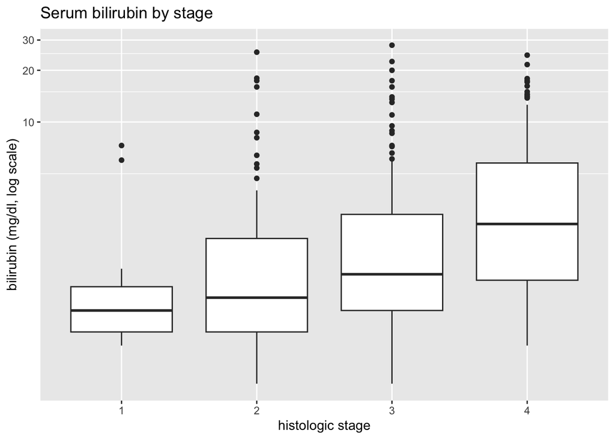

```r
q1_table <- q1 %>%
  group_by(stage) %>%
  summarise(
    bili_median = median(bili),
    bili_mean = mean(bili),
    albumin_median = median(albumin),
    albmin_mean = mean(albumin),
    n()
  )

#create boxplots
ggplot(q1, aes(x = factor(stage), y = bili)) +
  geom_boxplot() +
  coord_trans(y = "log10") +
  labs(title = "Serum bilirubin by stage",
       x = "histologic stage", y = "bilirubin (mg/dl, log scale)")
```

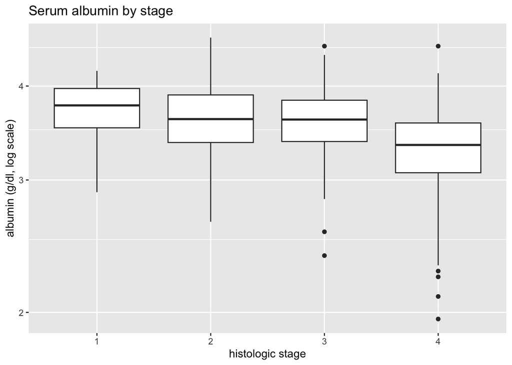

```r
ggplot(q1, aes(x = factor(stage), y = albumin)) +
  geom_boxplot() +
  coord_transform(y= "log10") +
  labs(title = "Serum albumin by stage",
       x = "histologic stage", y = "albumin (g/dl, log scale)")
```

## Question 2

```r
q2 <- pbc %>%
  select(id, status, time, bili, albumin) %>%
  mutate(
    died = status == 2,
    # Split into quartiles (Q1 = lowest)
    bili_group = factor(paste0("Q", ntile(bili, 4))),
    alb_group = factor(paste0("Q", ntile(albumin, 4)))
  )
```